# ENMTools 1.0: an R package for comparative ecological biogeography - Warren - - Ecography - Wiley Online Library

Software note

Free Access

# ENMTools 1.0: an R package for comparative ecological biogeography

[Dan L. Warren](https://onlinelibrary.wiley.com/action/doSearch?ContribAuthorStored=Warren%2C+Dan+L)

[Nicholas J. Matzke](https://onlinelibrary.wiley.com/action/doSearch?ContribAuthorStored=Matzke%2C+Nicholas+J)

[Marcel Cardillo](https://onlinelibrary.wiley.com/action/doSearch?ContribAuthorStored=Cardillo%2C+Marcel)

[John B. Baumgartner](https://onlinelibrary.wiley.com/action/doSearch?ContribAuthorStored=Baumgartner%2C+John+B)

[Linda J. Beaumont](https://onlinelibrary.wiley.com/action/doSearch?ContribAuthorStored=Beaumont%2C+Linda+J)

[Michael Turelli](https://onlinelibrary.wiley.com/action/doSearch?ContribAuthorStored=Turelli%2C+Michael)

[Richard E. Glor](https://onlinelibrary.wiley.com/action/doSearch?ContribAuthorStored=Glor%2C+Richard+E)

[Nicholas A. Huron](https://onlinelibrary.wiley.com/action/doSearch?ContribAuthorStored=Huron%2C+Nicholas+A)

[Marianna Simões](https://onlinelibrary.wiley.com/action/doSearch?ContribAuthorStored=Sim%C3%B5es%2C+Marianna)

… See all authors

First published: 19 January 2021

https://doi.org/10.1111/ecog.05485

## Abstract

The ENMTools software package was introduced in 2008 as a platform for making measurements on environmental niche models (ENMs, frequently referred to as species distribution models or SDMs), and for using those measurements in the context of newly developed Monte Carlo tests to evaluate hypotheses regarding niche evolution. Additional functionality was later added for model selection and simulation from ENMs, and the software package has been quite widely used. ENMTools was initially implemented as a Perl script, which was also compiled into an executable file for various platforms. However, the package had a number of significant limitations; it was only designed to fit models using Maxent, it relied on a specific Perl distribution to function, and its internal structure made it difficult to maintain and expand. Subsequently, the R programming language became the platform of choice for most ENM studies, making ENMTools less usable for many practitioners. Here we introduce a new R version of ENMTools that implements much of the functionality of its predecessor as well as numerous additions that simplify the construction, comparison and evaluation of niche models. These additions include new metrics for model fit, methods of measuring ENM overlap, and methods for testing evolutionary hypotheses. The new version of ENMTools is also designed to work within the expanding universe of R tools for ecological biogeography, and as such includes greatly simplified interfaces for analyses from several other R packages.

## Introduction

Here we describe the new ENMTools R package ver. 1.0, which reproduces the core functionality of the original ENMTools (Warren et al. 2010), but adds significant new functionality. It interfaces with many more modeling algorithms, performs several new statistical tests, and provides a unified interface for many different model types with automatic data processing, model construction, model evaluation and visualization. It provides new data structures designed specifically to simplify the addition of new modeling algorithms, and provides streamlined interfaces for some existing R packages including ecospat (Di Cola et al. 2017), vip (Greenwell and Boehmke 2020), CalibratR (Schwarz and Heider 2019) and phyloclim (Heibl et al. 2018).

## Functionality

### Species and clade objects

One of ENMTools' primary functions is to test hypotheses about similarity between environmental niche estimates for groups of organisms. To simplify this process, we have created data structures that contain the information needed to build an ENM for a species. The first of these structures is an *enmtools.species* object, which contains a species name, species occurrence data and optional range data and background points. They are created by using the *enmtools.species* function, and formatting is checked using the *check.species* function. An *enmtools.clade* object contains a list of *enmtools.species* objects and a phylogeny imported with the R package ape (Paradis and Schliep 2018). These objects are created using the *enmtools.clade* function, and can be checked for formatting by using the *check.clade* function.

### Building and refining niche and distribution models

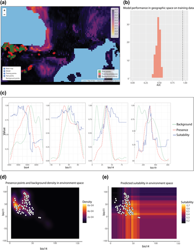

**Figure 1**

Sample model outputs from an *enmtools.model* object. Panel (a) shows a screen capture of an interactive plot that can be called on any *enmtools.model* object using the interactive.plot function. These visualizations can be panned and zoomed, with various layers being turned on and off to facilitate model and data exploration. Panel (b) shows the partial output of a randomization test based on Raes and ter Steege (2007), indicating that the predictive power of the model far exceeds that expected under the null hypothesis. Response curves (panel c) are presented in the context of the density distribution of each environmental variable in the species' occurrences as well as in the background data. Panels (d) and (e) show bivariate heat maps depicting the same information. Occurrence data points are represented by white points.

ENMTools provides additional support for model refinement by implementing a simplified interface for variable selection using the vip package (Greenwell and Boehmke 2020) and visualization of correlations between predictors (Fig. 2). Two visualizations are available: a cluster plot, which does multidimensional scaling (MDS) on the correlation matrix and then plots the results in a two dimensional space so that more correlated predictors are closer to each other (Fig. 2B), and a heatmap, where colors represent the Pearson correlation coefficient between predictors (Fig. 2C). ENMTools also provides methods to measure model calibration using continuous Boyce index (Hirzel et al. 2006) as well as expected and maximum calibration error, and allows recalibration via the CalibratR, caret and ecospat packages, along with automated conversion of recalibrated models to suitability rasters (Kuhn 2008, Di Cola et al. 2017, Schwarz and Heider 2019). We note here that expected and maximum calibration error are highly sensitive to prevalence, and should be used with caution.

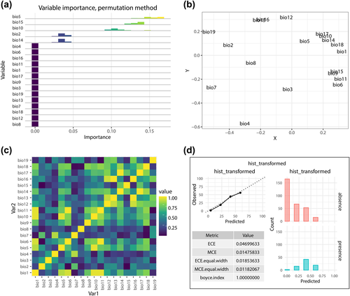

**Figure 2**

Variable selection and model recalibration in ENMTools. ENMTools implements a simplified interface for conducting tests of variable importance using several different methods, and plotting those results (panel a) using the enmtools.vip function. In order to explore multicollinearity of predictors, the raster.cor.plot function also provides visualizations of correlation matrices using MDS scaling to group correlated variables as well as pairwise heatmaps (panels b–c). Panel (d) shows the output of the enmtools.calibrate function, which allows users to measure model calibration and recalibrate models using a wide array of different methods.

### Metrics of ENM breadth and overlap

The initial version of ENMTools (Warren et al. 2010) introduced metrics of niche breadth and niche overlap on ENMs. Breadth metrics (B1 and B2, Levins 1968) measure the uniformity of the geographic distribution of suitability scores for a model, while niche overlap metrics (*D*, Schoener 1968; *I*, Warren et al. 2008) measure the similarity of the distribution of suitable habitat for a pair of models. The new ENMTools adds the use of the rank correlation coefficient *rho* (Spearman 1904) to measure niche overlap from ENMs. This addition is intended to supplement, rather than replace, the existing metrics and the choice of metric is intended to be driven by the goals of a given study. *D* and *I* will emphasize the potential for a pair of species (or lineages) to interact in a given geographic space, while *rho* will emphasize differences in the estimated physiological response to the predictor variables. Statistically, this is due to the fact *D* and *I* measure the similarity in the numerical value of suitability in a given set of conditions, while *rho* emphasizes the direction of response to the environmental gradient (for details <[https://enmtools.blogspot.com/2018/10/why‐add‐correlations‐for‐suitability.html](https://enmtools.blogspot.com/2018/10/why-add-correlations-for-suitability.html)>). The new ENMTools further extends these metrics by allowing users to measure them in the N‐dimensional environment space defined by the predictors used in model construction (Warren et al. 2019).

### Hypothesis testing for species pairs

The primary purpose of the ENMTools R package is, as with previous versions, to test hypotheses regarding the evolution of differences between species, populations and other groups of organisms using ENMs. Many of these tests are conducted by comparing the overlap between empirical species distribution models to a null distribution. These distributions are estimated using Monte Carlo methods, in which species occurrences are chosen randomly in a manner consistent with the chosen null hypothesis. While older versions only implemented these tests using Maxent models, the new R version allows users to conduct tests using any method that has an accompanying ENMTools modeling function (above). A brief description of each test follows.

#### Identity test

The identity (also called equivalency) test was first developed in Warren et al. (2008) to address whether a pair of closely related species are effectively identical in their realized environmental distributions. In this test, models are built using the empirical data for each species, and overlap is measured between them. The null distribution is constructed by repeatedly randomizing the group identity (e.g. species or lineage) of each data point, keeping the sample size for each group consistent with the empirical data. Models are built for each replicate, and overlap between them is measured. The distribution of overlaps constructed in this way reflects the expected similarity between groups if their environmental distributions represent repeated draws from the same underlying distribution. By comparing the empirical value to this distribution (Fig. 3), we can reject (or fail to reject) this hypothesis at a given level of confidence (e.g. p < 0.05).

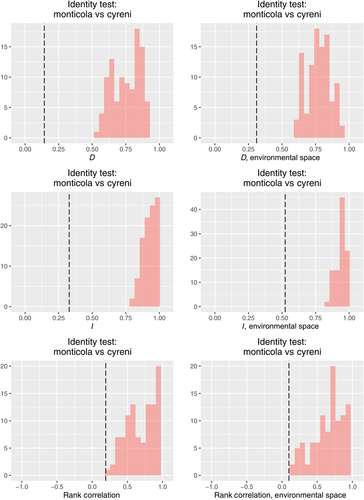

**Figure 3**

Sample output for identity test for all three implemented niche overlap metrics. Histograms represent the distribution of overlaps for each metric from the null distribution, while the dashed vertical line represents the overlap between the models built using the empirical data.

#### Background test

In many cases, groups that are partially or fully allopatric will have different suites of environments available to them. As such they will often be found to have different environmental distributions for reasons that may not reflect any underlying divergence in ecological tolerances or preferences. To correct for the differential availability of habitat for allopatric groups, Warren et al. (2008) developed the ‘background test', also known as the ‘similarity test'. This method is broadly similar to the identity test, but the null distribution is constructed by building ENMs using randomly chosen points from the broad region where each group lives, rather than points where the species has actually been detected. The ENMs thus constructed represent the distributions of available habitat in each geographic region, rather than the environmental associations of either group. The null distribution therefore reflects the expected similarity between groups based on the available environments, and rejecting the null hypothesis therefore implies that species are more (or less) similar in their environmental distributions than expected given their respective ranges. As originally implemented, this test was conducted by randomizing occurrences for each group one at a time; the null distribution was constructed by comparing randomized points from one species' range to the empirical points for the other species' range. The ENMTools R package allows users to choose between this method (an ‘asymmetric' background test) and one in which both groups' points are chosen randomly in each replicate (a ‘symmetric' background test). This latter approach mirrors one implemented for kernel density niche estimates in ecospat (Di Cola et al. 2017).

#### Ecospat tests

Broennimann et al. (2012) developed methods for constructing kernel density estimates of species' environmental distributions and the distributions of available environments to quantify niche overlap in a two‐dimensional environment space, and used these to conduct hypothesis tests similar to those implemented in ENMTools (Warren et al. 2010). The R version of ENMTools provides a greatly simplified user interface for ecospat hypothesis tests via the use of *enmtools.species* objects. This includes automatically conducting principal components analysis when more than two predictor layers are provided, in order to reduce the predictors to a two dimensional environment space. The new ENMTools also implements identity and background tests in N‐dimensional environment space without PCA using the new environment space overlap metrics introduced in Warren et al. (2019).

#### Rangebreak tests

Glor and Warren (2011) introduced Monte Carlo tests using ENMs to explore the environmental and historical significance of biogeographic boundaries. In these tests, the overlap between the ENMs for two allopatric groups is compared to a null distribution that is constructed by randomizing the location and shape of the biogeographic boundary that separates them. The null distribution in this case represents the expected overlap between a pair of groups (typically species) that are allopatric for reasons uncorrelated with the distribution of environmental variables in the study region. Rejection of this null supports the alternative hypothesis that the location of the boundary between the species' distributions in the empirical data partitions the two sets of occurrences into environmental distributions that are unusually disjunct.

#### MOSES tests

Finally, ENMTools provides basic functionality for a new variety of test that goes by the acronym MOSES (MOdel Selection for Ecological Similarity). This method represents a parametric approach to the question of similarity between species. Using the Akaike information criterion (Burnham and Anderson 2002), MOSES treats the question of ecological similarity as a model‐partitioning problem. By comparing the combined AIC of models built for two lineages separately to a model built for the combined presence/background data for both lineages, MOSES effectively determines whether the two lineages are sufficiently different in their environmental associations to justify the additional parameters needed to estimate separate models for each of them. This method is currently in development and is intended only for experimental use; simulation studies to test its efficacy are underway.

### Hypothesis testing for clades

Measurements of similarity between species (e.g. range overlap) are difficult to analyze in the context of traditional phylogenetic comparative methods, as measurements are made across nodes of the phylogeny (i.e. comparisons between two or more species) rather than at the tips. Age‐overlap correlation (AOC) is a generalization of age‐range correlation methods (ARC), which allow the analysis of overlap‐ and distance‐style metrics in a phylogenetic context (Barraclough et al. 2000, Fitzpatrick and Turelli 2006, Grossenbacher and Whittall 2011, Cardillo and Warren 2016). In an AOC analysis, the average overlap across each internal node is calculated using an algorithm that accounts for tree topology, and this average overlap is regressed against node age. As overlap metrics are often bounded [0,1] and any given species' range will be used to calculate average overlaps across multiple internal nodes, residuals from these regressions are not expected to be independent or normally distributed. Statistical significance is therefore estimated by using a Monte Carlo test. Each replicate randomizes the identity of the tips of the phylogeny, recalculates overlap at each internal node, and performs a linear regression. The slope and intercept from the regression on empirical data are compared to the null distribution of slopes and intercepts from the Monte Carlo replicates, allowing users to test 1) whether there is more or less overlap between recently diverged species than expected and 2) whether overlap between tips increases or decreases over evolutionary time.

ENMTools streamlines age‐overlap correlation analyses, allowing users to simply use the function *enmtools.aoc* on an *enmtools.clade* object (Fig. 4). For range overlap, point pattern similarity and ENM overlap in both geographic and environment space, ENMTools can automatically calculate overlaps, including automated model construction for measurements that require ENMs. Alternatively, users can supply their own overlap matrix containing any measurement of ecological similarity.

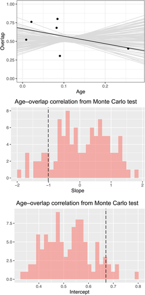

**Figure 4**

Sample output for age‐overlap correlation test. The top panel shows the distribution of topologically averaged overlaps in the empirical data (black line and points), as well as the distribution of linear regressions from the Monte Carlo replicates (grey lines). The middle and bottom panels show the distribution of slopes and intercepts separately, with pink histograms representing the values from Monte Carlo replicates and vertical dashed lines representing the values from the empirical data.

### Training resources

ENMTools contains an extensive vignette introducing much of the core functionality of the package. Additionally, a set of video introductions to many of the concepts and functions implemented in ENMTools are available at <[https://www.youtube.com/playlist?list=PLw‐jIvFxpgIBgNzIbfh52‐TQyTEbcSvSH](https://www.youtube.com/playlist?list=PLw-jIvFxpgIBgNzIbfh52-TQyTEbcSvSH)> and in‐depth training scripts are available at <[https://github.com/danlwarren/ENMTools‐Tutorials](https://github.com/danlwarren/ENMTools-Tutorials)>. These materials are continuously being updated and new content added as new functionality is implemented.

## Conclusions

This new version of ENMTools provides a toolkit of both novel and now‐standard methods that will be accessible to end users at all skill levels, thereby contributing to further development of comparative ecological biogeography. This release also signals the coming end of support for older versions of ENMTools (Warren et al. 2010), which have become increasingly difficult to maintain and troubleshoot. Further, we hope that the deployment of the ENMTools R package on GitHub helps to encourage community contributions to this toolkit, and that the species‐ and clade‐oriented approach developed here serves to encourage further efforts to make sophisticated biogeographic analyses more widely accessible.

*Acknowledgements* – The authors would like to acknowledge Rob Lanfear for coming up with the name MOSES, as well as Haris Saslis‐Lagoudakis and the Transmitting Science organization for assistance in developing training materials.

*Funding* – DLW was funded by ARC DECRA award # DE140101675 and supported by subsidy funding to OIST. NJM was funded by Marsden grants 16‐UOA‐277 and 18‐UOA‐034, and U. Auckland FRDF #3722433. JCP is funded by a doctoral fellowship supported by the Agencia Canaria de la Investigación, Innovación y Sociedad de la Información and the European Social Fund (Operational Programme of the Canary Islands 2014‐2020). MC acknowledges support from Australian Research Council Discovery Project DP110103168.

### Author contributions

**Julien Piquet**: Conceptualization (supporting); Software (supporting). **Dan Warren**: Conceptualization (lead); Formal analysis (equal); Methodology (equal); Project administration (equal); Software (lead); Writing – original draft (lead). **Nicholas Matzke**: Conceptualization (supporting); Software (supporting). **Marcel Cardillo**: Conceptualization (equal); Writing – review and editing (equal). **John Baumgartner**: Conceptualization (equal); Methodology (equal); Software (supporting). **Linda Beaumont**: Conceptualization (equal); Methodology (equal). **Michael Turelli**: Conceptualization (equal); Methodology (equal); Writing – original draft (equal); Writing – review and editing (equal). **Richard Glor**: Conceptualization (equal); Methodology (equal). **Nicholas Huron**: Conceptualization (supporting); Software (supporting). **Marianna Simoes**: Conceptualization (supporting); Methodology (supporting); Resources (supporting). **Teresa Iglesias**: Conceptualization (supporting); Methodology (supporting); Writing – original draft (supporting). **Russell Dinnage**: Conceptualization (equal); Methodology (equal); Project administration (equal); Software (equal); Writing – original draft (supporting).